# Kindergarten Menu Food-Group Classification — M505

Name: Sailu Laly Sajeev

Student_ID: GH1043653

Course: M505 Intro to AI and Machine Learning

**Dataset**: Open Food Facts (Kaggle), version 5, ODbL v1.0.

**URL**: https://www.kaggle.com/datasets/openfoodfacts/world-food-facts

**Business task**: Suggest the food group of a packaged product from its ingredient list and declared nutrients, so Kita kitchen staff can plan lunches against DGE food-group rules faster.

## INTRODUCTION

Kitas that follow the *DGE-Qualitätsstandard für die Verpflegung in Kitas* plan lunches by food-group frequencies, so every purchased product must first be assigned to a food group. This project trains and compares scikit-learn classifiers that suggest the food group for staff review; Step 9 shows how confirmed groups feed DGE, nutrition and allergen checks.

**Problem statement:** supervised multiclass classification (8 classes) at product level – not menu level. **Primary metric: macro-F1**, because rare but planning-critical groups (fruits & vegetables, fish/meat/eggs) must weigh as much as the large sugary-snack class.

## DATA COLLECTION STRATEGY

- **Source:** Open Food Facts on Kaggle (crowd-sourced; 356,027 products, 163 columns, 2017 snapshot) – public, ODbL-licensed, with ingredient text, nutrients per 100 g and a documented food-group label (`pnns_groups_1`); two other Kaggle candidates were rejected (`dataset_card.md`).
- **Download:** programmatic and anonymous with `kagglehub.dataset_download("openfoodfacts/world-food-facts")` (`scripts/01_download_kaggle_off.py`); the 1.0 GB file's SHA-256 is recorded in `data/raw/extract_meta.json`.
- **Subset:** `scripts/02_build_subset.py` applies the filters printed in Step 2, merges duplicate products, converts energy from kJ to kcal and draws a **stratified random sample of 12,000**, shipped with the project.
- **In production:** the same fields from supplier sheets or barcode look-ups; staff corrections become new labels.

## DATASET OVERVIEW

| Item | Value |
| --- | --- |
| Rows | 12,001 sampled of 47,949 eligible |
| Inputs | ingredient text (TF-IDF) + 8 nutrients per 100 g/ml: energy (kcal), fat, saturated fat, carbohydrates, sugars, fibre, protein, salt |
| Target | `food_group_l1` – PNNS level-1 food group, 8 classes (composite foods excluded); not identical to DGE groups (`dataset_card.md`) |
| Language | mixed; a stop-word heuristic guesses ~69 % French, 6 % English, 5 % German, 4 % Spanish |
| Excluded (leakage) | category tags, Nutri-Score, product names |

Nutrients are per 100 g (100 ml for liquids).

## Step 1: Importing necessary libraries

```python
import json, warnings, numpy as np, pandas as pd, matplotlib.pyplot as plt, sklearn, sklearn.metrics as skm
from sklearn.model_selection import train_test_split, StratifiedKFold, cross_validate, GridSearchCV, learning_curve
from sklearn.pipeline import Pipeline
from sklearn.compose import ColumnTransformer
from sklearn.feature_extraction.text import TfidfVectorizer
from sklearn.impute import SimpleImputer
from sklearn.preprocessing import StandardScaler
from sklearn.dummy import DummyClassifier
from sklearn.linear_model import LogisticRegression
from sklearn.ensemble import RandomForestClassifier
warnings.filterwarnings('ignore', category=sklearn.exceptions.ConvergenceWarning)
RS, R = 42, 'results/'; pd.set_option('display.max_colwidth', 120)
def fig(name): plt.tight_layout(); plt.savefig(R + name + '.png', dpi=110); plt.show()
```

## Step 2: Reading the Dataset

```python
df = pd.read_csv('data/processed/off_foodgroups_sample.csv'); NUT = [c for c in df.columns if c.endswith('_100g')]  # 8 nutrients
print(pd.Series(json.load(open(R + 'data_funnel.json')), name='products after each filter'))
df.head()
```

```
F0_kaggle_products                      356027
F1_known_food_group                      85402
F2_has_ingredients                       71415
F3_has_core_nutrients                    61872
F4_kept_classes                          55320
F5a_duplicate_groups_total                2859
F5b_conflicting_label_groups_dropped        81
F5c_after_dedup_one_per_group            47949
F6_stratified_sample                     12001
Name: products after each filter, dtype: int64
```

|  | code | product_name | brands | countries_tags | lang_guess | ingredients_text | food_group_l1 | pnns_groups_2 | allergens | traces_tags | serving_size | last_modified_datetime | energy_kcal_100g | fat_100g | saturated_fat_100g | carbohydrates_100g | sugars_100g | fiber_100g | proteins_100g | salt_100g |
| --- | --- | --- | --- | --- | --- | --- | --- | --- | --- | --- | --- | --- | --- | --- | --- | --- | --- | --- | --- | --- |
| 0 | 3421557502002 | Muesli Croustillant Tradition | Terres et Céréales BIO | en:france | fr | flocons d' avoine 57.5%, sucre de canne non raffiné, huile de tournesol, billettes de céréales (riz, blé , avoine , ... | cereals-and-potatoes | Breakfast cereals | avoine, blé, avoine, blé, orge | en:peanuts,en:sesame-seeds,en:soybeans,fr:produits-laitiers | 40 g | 2017-06-21T13:23:18Z | 424.7 | 13.2 | 1.7 | 64.0 | 20.0 | 7.0 | 8.5 | 0.03000 |
| 1 | 2000000013844 | Alubias rojas cocidas en conserva | Monjardín,//Propiedad de://,José Salcedo Soria S.L. | en:spain | es | Alubias rojas*, agua y sal. (* Ingredientes procedentes de la agricultura ecológica). | cereals-and-potatoes | Legumes | NaN | NaN | NaN | 2015-06-20T23:37:36Z | 74.8 | 0.6 | 0.4 | 10.5 | 0.3 | NaN | 4.3 | 0.89916 |
| 2 | 3760204450052 | Confiserie gélifiée Caiman bi-texture citrique | Distribution Confiseries Bonbons,Golec | en:france | fr | Sucre, sirop de glucose, gélatine, eau, acidifiants (acide citrique, acide malique), arômes, colorants (E163, E160c,... | sugary-snacks | Sweets | NaN | en:gluten,en:milk,en:nuts,en:peanuts,en:soybeans | NaN | 2016-09-08T11:11:57Z | 327.0 | 0.0 | 0.0 | 75.0 | 70.0 | NaN | 6.4 | 0.03000 |
| 3 | 3280960010036 | Rosette | Sélection des Ducs | en:france | fr | Viande de porc, sel, lactose , dextrose, poivre blanc, sucre, ail en poudre, conservateur : nitrate de potassium, mu... | fish-meat-eggs | Processed meat | lactose | en:nuts | NaN | 2015-06-18T17:06:28Z | 416.1 | 34.0 | 14.0 | 1.4 | 0.7 | NaN | 27.0 | 5.00000 |
| 4 | 3760225491317 | Nectar douceur de pêche | Cidou | en:france | fr | Jus de raisin à base de concentré (42%), purée de pêche (34%), jus d'orange à base de concentré, eau, vitamine C. In... | beverages | Fruit nectars | NaN | NaN | NaN | 2017-08-15T07:24:47Z | 50.0 | 0.2 | 0.0 | 11.5 | 11.2 | 0.0 | 0.4 | 0.00000 |

```python
df.info()
```

```
<class 'pandas.core.frame.DataFrame'>
RangeIndex: 12001 entries, 0 to 12000
Data columns (total 20 columns):
 #   Column                  Non-Null Count  Dtype
---  ------                  --------------  -----
 0   code                    12001 non-null  int64
 1   product_name            11991 non-null  object
 2   brands                  11961 non-null  object
 3   countries_tags          11993 non-null  object
 4   lang_guess              12001 non-null  object
 5   ingredients_text        12001 non-null  object
 6   food_group_l1           12001 non-null  object
 7   pnns_groups_2           12001 non-null  object
 8   allergens               5085 non-null   object
 9   traces_tags             4034 non-null   object
 10  serving_size            5740 non-null   object
 11  last_modified_datetime  12001 non-null  object
 12  energy_kcal_100g        12001 non-null  float64
 13  fat_100g                12001 non-null  float64
 14  saturated_fat_100g      11502 non-null  float64
 15  carbohydrates_100g      12001 non-null  float64
 16  sugars_100g             11551 non-null  float64
 17  fiber_100g              7019 non-null   float64
 18  proteins_100g           12001 non-null  float64
 19  salt_100g               11554 non-null  float64
dtypes: float64(8), int64(1), object(11)
memory usage: 1.8+ MB
```

## Step 3: Missing Values and Data Quality Issues

```
{'code': 0, 'product_name': 10, 'brands': 40, 'countries_tags': 8, 'lang_guess': 0, 'ingredients_text': 0, 'food_group_l1': 0, 'pnns_groups_2': 0, 'allergens': 6916, 'traces_tags': 7967, 'serving_size': 6261, 'last_modified_datetime': 0, 'energy_kcal_100g': 0, 'fat_100g': 0, 'saturated_fat_100g': 49…
duplicate rows: 0 | duplicate texts: 0
impossible values - negative: 0 | >100 g: 1 | >900 kcal: 51
```

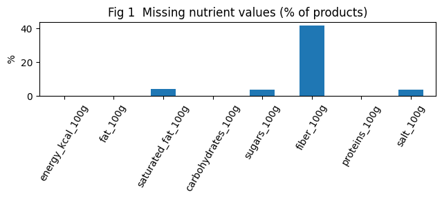

```python
print(df.isna().sum().to_dict())
print('duplicate rows:', df.duplicated().sum(), '| duplicate texts:', df.ingredients_text.duplicated().sum())
print('impossible values - negative:', int((df[NUT] < 0).sum().sum()), '| >100 g:', int((df[NUT[1:]] > 100).sum().sum()), '| >900 kcal:', int((df.energy_kcal_100g > 900).sum()))
(df[NUT].isna().mean() * 100).plot.bar(figsize=(6.5, 3), rot=60, title='Fig 1  Missing nutrient values (% of products)', ylabel='%'); fig('fig1_missing')
```

**Data-quality takeaways.** Allergen/trace fields are mostly empty, so absence never means "allergen-free" (Step 9). **Fibre is missing for ~41 %**, saturated fat, sugars and salt for ~4 %; missing means *not declared*, not zero, so imputation adds a missing indicator. A few values are physically impossible (> 100 g per 100 g, > 900 kcal). Texts contain OCR noise and several languages; crowd-sourced labels contain noise (nuts under *salty snacks*). No duplicates remain (variants merged before sampling).

## Step 4: Exploratory Data Analysis (EDA)

#### 1 — Target distribution

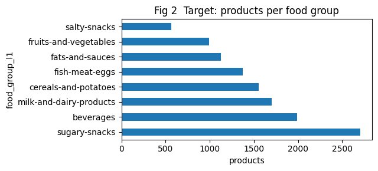

```python
df.food_group_l1.value_counts().plot.barh(figsize=(6.5, 3), title='Fig 2  Target: products per food group', xlabel='products'); fig('fig2_target')
```

#### 2 — Features

```
                     mean  min    50%    max
energy_kcal_100g    269.0  0.0  249.8  999.0
fat_100g             14.0  0.0    5.5  100.0
saturated_fat_100g    5.7  0.0    1.8  100.0
carbohydrates_100g   28.3  0.0   13.8  100.0
sugars_100g          15.2  0.0    6.5  145.0
fiber_100g            2.7  0.0    1.5   98.5
proteins_100g         6.7  0.0    4.8   85.0
salt_100g             0.8  0.0    0.3   61.0
```

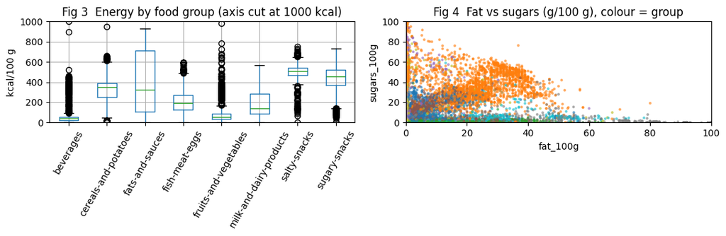

```python
print(df[NUT].describe().round(1).T[['mean', 'min', '50%', 'max']])
f, ax = plt.subplots(1, 2, figsize=(11, 3.8))
df.boxplot('energy_kcal_100g', by='food_group_l1', ax=ax[0], rot=60); ax[0].set(title='Fig 3  Energy by food group (axis cut at 1000 kcal)', xlabel='', ylabel='kcal/100 g', ylim=(0, 1000))
df.plot.scatter('fat_100g', 'sugars_100g', c=pd.factorize(df.food_group_l1)[0], cmap='tab10', s=4, alpha=.5, ax=ax[1], colorbar=False, xlim=(0, 100), ylim=(0, 100), title='Fig 4  Fat vs sugars (g/100 g), colour = group')
plt.suptitle(''); fig('fig3_4_features')
```

**EDA Takeaways.** *Fig 2*: sugary snacks are ~23 % of products, salty snacks ~5 % – hence macro-F1 and class weights. *Fig 3*: energy separates fats from beverages and vegetables but overlaps between cereals, snacks and dairy – nutrients alone cannot solve the task. *Fig 4*: *fat + sugars ≤ 100 g*; sugary snacks form the upper band, fats the right edge.

## Step 5: Data Cleaning and Train/Test Split

#### Cleaning

```python
dfc = df.copy()
dfc.loc[dfc.energy_kcal_100g > 900, 'energy_kcal_100g'] = np.nan          # more than pure fat is impossible
for c in NUT[1:]: dfc.loc[(dfc[c] < 0) | (dfc[c] > 100), c] = np.nan        # unknown, never zero
print('values set to unknown:', int(dfc[NUT].isna().sum().sum() - df[NUT].isna().sum().sum()))
hard = (dfc.fat_100g + dfc.carbohydrates_100g + dfc.proteins_100g) > 101
dfc = dfc[~hard]; print('rows dropped (fat+carbs+protein > 101 g):', int(hard.sum()))
```

```
values set to unknown: 52
rows dropped (fat+carbs+protein > 101 g): 14
```

#### Stratified 80/20 train/test split

```python
X, y = dfc[['ingredients_text'] + NUT], dfc.food_group_l1
X_tr, X_te, y_tr, y_te = train_test_split(X, y, test_size=0.2, stratify=y, random_state=RS)
print('train', X_tr.shape, '| test', X_te.shape, '| test class shares', y_te.value_counts(normalize=True).round(2).to_dict())
```

```
train (9589, 9) | test (2398, 9) | test class shares {'sugary-snacks': 0.23, 'beverages': 0.17, 'milk-and-dairy-products': 0.14, 'cereals-and-potatoes': 0.13, 'fish-meat-eggs': 0.11, 'fats-and-sauces': 0.09, 'fruits-and-vegetables': 0.08, 'salty-snacks': 0.05}
```

**Preprocessing & Split Summary.** *Split*: 80/20 stratified, fixed seed, on independent products (duplicates merged *before* splitting); the test set is used **once**, in Step 8. *Text*: TF-IDF uni-/bigrams (`min_df=3`, ≤ 5,000 terms, sublinear tf), fitted **inside each training fold**. *Numeric*: median imputation + missing indicator; B adds `StandardScaler`.

## Step 6: Preprocessing Comparison — Strategy A (unscaled) vs B (StandardScaler)

Same TF-IDF, same imputation, the **same 5 stratified folds** – only the scaler differs. **Logistic Regression**: one weight per term and nutrient per class – fast, readable, linear only. **Random Forest**: decorrelated trees on bootstrap samples with random feature subsets – non-linear, scale-robust, less interpretable.

```python
def prep(scale):
    num = [('imp', SimpleImputer(strategy='median', add_indicator=True))] + ([('sc', StandardScaler())] if scale else [])
    return ColumnTransformer([('txt', TfidfVectorizer(ngram_range=(1, 2), min_df=3, max_features=5000, sublinear_tf=True), 'ingredients_text'), ('num', Pipeline(num), NUT)])
models = {'Dummy': DummyClassifier(strategy='most_frequent'), 'LogReg': LogisticRegression(max_iter=2000, class_weight='balanced'),
          'RandomForest': RandomForestClassifier(class_weight='balanced_subsample', random_state=RS, n_jobs=-1)}
cv = StratifiedKFold(5, shuffle=True, random_state=RS)
```

#### Comparison table

```
A: unscaled lbfgs iterations per fold (limit 2000): [2000, 2000, 2000, 2000, 2000]
```

```
B: scaled lbfgs iterations per fold (limit 2000): [119, 126, 126, 120, 120]
```

```
       model    strategy  macro_f1    sd  fit_s
       Dummy A: unscaled     0.046 0.000  0.407
      LogReg A: unscaled     0.804 0.007 32.535
      LogReg   B: scaled     0.872 0.008  2.270
RandomForest A: unscaled     0.888 0.007  3.402
RandomForest   B: scaled     0.886 0.003  3.448
```

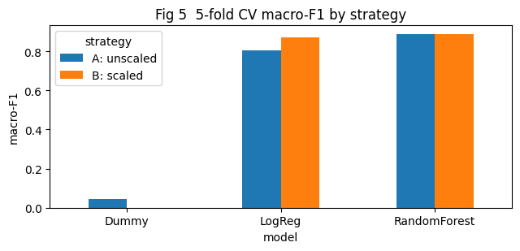

```python
rows = []
for m, est in models.items():
    for strat, sc in [('A: unscaled', False), ('B: scaled', True)]:
        if m == 'Dummy' and sc: continue
        r = cross_validate(Pipeline([('prep', prep(sc)), ('model', est)]), X_tr, y_tr, cv=cv, scoring='f1_macro', return_estimator=True)
        rows.append(dict(model=m, strategy=strat, macro_f1=r['test_score'].mean(), sd=r['test_score'].std(), fit_s=r['fit_time'].mean()))
        if m == 'LogReg': print(strat, 'lbfgs iterations per fold (limit 2000):', [int(e['model'].n_iter_[0]) for e in r['estimator']])
cmp = pd.DataFrame(rows).round(3); cmp.to_csv(R + 'preprocessing_comparison.csv', index=False); print(cmp.to_string(index=False))
cmp.pivot(index='model', columns='strategy', values='macro_f1').plot.bar(figsize=(6.5, 3.2), rot=0, ylabel='macro-F1', title='Fig 5  5-fold CV macro-F1 by strategy'); fig('fig5_preprocessing')
```

**Preprocessing Takeaways (Fig 5).** Scaling changes nothing for the dummy and only noise for the forest: trees split on thresholds, and a monotone rescaling keeps the same splits. Logistic Regression is sensitive: unscaled kcal values in the hundreds next to TF-IDF weights in [0, 1] ill-condition the loss – lbfgs **hits the 2,000-iteration limit in every fold** and macro-F1 drops; scaled, it converges quickly. Strategy B is used from here on.

## Step 7: Hyperparameter Tuning and Best Model

#### Grid search (training data only)

`GridSearchCV` with stratified folds and macro-F1. **LogReg:** `C`, the inverse regularisation strength (small C = strong shrinkage). **RandomForest:** `n_estimators`, `max_depth` (limits overfitting), `min_samples_leaf`, `max_features`; three folds keep 16 configurations affordable.

```python
grids = {'LogReg': (LogisticRegression(max_iter=3000, class_weight='balanced'), {'model__C': [0.01, 0.1, 1, 10, 100]}, 5),
         'RandomForest': (RandomForestClassifier(class_weight='balanced_subsample', random_state=RS, n_jobs=-1),
                          {'model__n_estimators': [100, 300], 'model__max_depth': [20, None], 'model__min_samples_leaf': [1, 3], 'model__max_features': ['sqrt', 0.05]}, 3)}
best, cvres, val_best, params = {}, {}, {}, {}
for m, (est, grid, k) in grids.items():
    gs = GridSearchCV(Pipeline([('prep', prep(True)), ('model', est)]), grid, cv=StratifiedKFold(k, shuffle=True, random_state=RS), scoring='f1_macro').fit(X_tr, y_tr)
    best[m], val_best[m], params[m] = gs.best_estimator_, gs.best_score_, gs.best_params_
    cvres[m] = pd.DataFrame(gs.cv_results_).filter(regex='param|mean|std').round(3); cvres[m].to_csv(R + f'tuning_{m}.csv', index=False)
    print(m, f'CV macro-F1 {gs.best_score_:.3f} ± {cvres[m].std_test_score[gs.best_index_]:.3f}')
```

```
LogReg CV macro-F1 0.884 ± 0.008
```

```
RandomForest CV macro-F1 0.893 ± 0.006
```

#### Hyperparameter effects

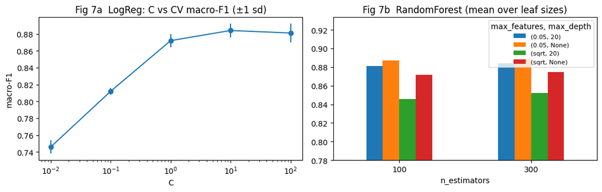

```python
f, ax = plt.subplots(1, 2, figsize=(11, 3.6))
ax[0].errorbar(cvres['LogReg'].param_model__C.astype(float), cvres['LogReg'].mean_test_score, yerr=cvres['LogReg'].std_test_score, marker='o')
ax[0].set(xscale='log', title='Fig 7a  LogReg: C vs CV macro-F1 (±1 sd)', xlabel='C', ylabel='macro-F1')
rf = cvres['RandomForest'].astype(str).assign(s=cvres['RandomForest'].mean_test_score)
rf.pivot_table(index='param_model__n_estimators', columns=['param_model__max_features', 'param_model__max_depth'], values='s').plot.bar(ax=ax[1], rot=0, ylim=(0.78, None), title='Fig 7b  RandomForest (mean over leaf sizes)', xlabel='n_estimators')
ax[1].legend(title='max_features, max_depth', fontsize=8); fig('fig7_hyperparameters')
```

#### Learning curves and best-model summary

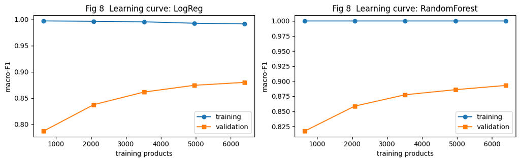

```
              CV macro-F1  \
LogReg              0.884
RandomForest        0.893

                                                                                                                best_parameters
LogReg                                                                                                         {'model__C': 10}
RandomForest  {'model__max_depth': None, 'model__max_features': 0.05, 'model__min_samples_leaf': 1, 'model__n_estimators': 300}
Best model: RandomForest
```

```python
f, ax = plt.subplots(1, 2, figsize=(11, 3.5))
for a, (m, est) in zip(ax, best.items()):
    n, tr, va = learning_curve(est, X_tr, y_tr, train_sizes=np.linspace(0.1, 1.0, 5), cv=StratifiedKFold(3, shuffle=True, random_state=RS), scoring='f1_macro')
    a.plot(n, tr.mean(1), 'o-', label='training'); a.plot(n, va.mean(1), 's-', label='validation'); a.legend(); a.set(title=f'Fig 8  Learning curve: {m}', xlabel='training products', ylabel='macro-F1')
fig('fig8_learning_curves')
best_model = max(val_best, key=val_best.get)
print(pd.Series(val_best).round(3).to_frame('CV macro-F1').assign(best_parameters=pd.Series(params))); print('Best model:', best_model)
```

**Tuning — Summary.** *Fig 7*: Logistic Regression shows the classic bias–variance shape (C = 0.01 underfits; the score peaks at C = 10). For the forest, more trees add little, unlimited depth beats depth 20, and more candidate features per split help on sparse text. *Fig 8*: both models fit the training data almost perfectly while validation scores still rise with more data – the gap is variance, so **more labelled products would help more than a more complex model**. The best model is chosen by CV macro-F1 before the test set is touched.

## Step 8: Evaluate the Best Model

#### Test-set evaluation (best model, frozen alternative, dummy)

```
              accuracy  balanced_accuracy  macro_f1
Dummy            0.225              0.125     0.046
LogReg           0.905              0.889     0.887
RandomForest     0.926              0.910     0.912
                         precision    recall  f1-score   support

              beverages      0.958     0.912     0.934       398
   cereals-and-potatoes      0.932     0.881     0.905       310
        fats-and-sauces      0.962     0.902     0.931       225
         fish-meat-eggs      0.935     0.996     0.965       275
  fruits-and-vegetables      0.872     0.859     0.865       198
milk-and-dairy-products      0.941     0.941     0.941       340
           salty-snacks      0.812     0.812     0.812       112
          sugary-snacks      0.915     0.974     0.943       540

               accuracy                          0.926      2398
              macro avg      0.916     0.910     0.912      2398
           weighted avg      0.926     0.926     0.925      2398
```

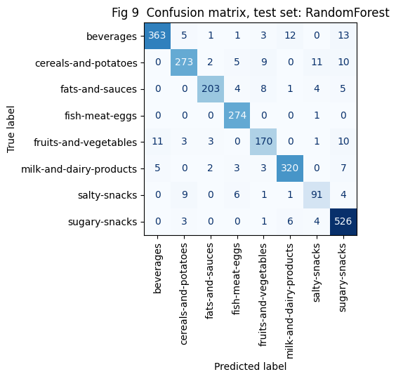

```python
final = best_model
finals = {'Dummy': Pipeline([('prep', prep(True)), ('model', DummyClassifier(strategy='most_frequent'))]).fit(X_tr, y_tr), **best}
pred = {m: est.predict(X_te) for m, est in finals.items()}
test = pd.DataFrame({m: dict(accuracy=skm.accuracy_score(y_te, p), balanced_accuracy=skm.balanced_accuracy_score(y_te, p), macro_f1=skm.f1_score(y_te, p, average='macro'))
                     for m, p in pred.items()}).T.round(3); test.to_csv(R + 'test_results.csv'); print(test)
rep = skm.classification_report(y_te, pred[final], digits=3); print(rep); open(R + 'classification_report.txt', 'w').write(rep)
f, a = plt.subplots(figsize=(6.5, 5.5)); skm.ConfusionMatrixDisplay.from_predictions(y_te, pred[final], ax=a, xticks_rotation='vertical', cmap='Blues', colorbar=False)
a.set_title(f'Fig 9  Confusion matrix, test set: {final}'); fig('fig9_confusion_matrix')
```

#### Error analysis and informative features

```python
p = pred[final]; err = X_te[p != y_te].assign(true=y_te[p != y_te], pred=p[p != y_te], name=dfc.product_name)
print(len(err), 'test errors; most frequent confusions:'); print(pd.crosstab(err.true, err.pred).stack().nlargest(5))
display(err.sample(6, random_state=RS)[['name', 'true', 'pred', 'ingredients_text']])
coef = pd.DataFrame(best['LogReg']['model'].coef_, index=best['LogReg'].classes_, columns=best['LogReg']['prep'].get_feature_names_out())
print('LogReg strongest terms per class:', {c: [t.split('__')[1] for t in coef.loc[c].nlargest(4).index] for c in coef.index})
```

```
178 test errors; most frequent confusions:
true                   pred
beverages              sugary-snacks              13
                       milk-and-dairy-products    12
cereals-and-potatoes   salty-snacks               11
fruits-and-vegetables  beverages                  11
cereals-and-potatoes   sugary-snacks              10
dtype: int64
```

|  | name | true | pred | ingredients_text |
| --- | --- | --- | --- | --- |
| 2313 | Pass-o-Guava | beverages | sugary-snacks | SUGAR, DRIED CANE SYBUP, MALTODEXTRIN, DEXTROSE, NATURAL FLAVORS, DRIED GUAVA PUREE, ClTRlB ACID, XANTHAN GUM, ASCOR... |
| 2932 | 2 éclairs café | sugary-snacks | milk-and-dairy-products | Crème café (77,8%) : eau, sucre, amidon modifié (pomme de terre), lait écrémé en poudre, matière grasse végétal (coc... |
| 9226 | Crispbits | salty-snacks | sugary-snacks | Patate Douce 85%, Huile De Palme, Sucre De Canne. |
| 1496 | Aceitunas negras enteras &quot;Carbonell&quot; Variedad Cacereña | fruits-and-vegetables | fats-and-sauces | Aceitunas cacereña, agua, sal, estabilizador: gluconato ferroso (E-579). Categoría: I. Calibre: 240/260. |
| 10444 | Chair de Tomates | fruits-and-vegetables | fats-and-sauces | Pulpe de tomates 90 %, purée de tomates 8 %, amidon modifié de maïs, sucre, sel. |
| 5236 | Mix Mexican | fruits-and-vegetables | salty-snacks | Maïs grillé piquant, (huile végétale, sel, arôme naturel), amandes grillées et salées, noix de cajou grillées et sal... |

```
LogReg strongest terms per class: {'beverages': ['jus', 'ml', 'thé', 'orange'], 'cereals-and-potatoes': ['blé dur', 'dur', 'complet', 'peanuts'], 'fats-and-sauces': ['vinaigre', 'vinegar', 'vin', 'tomates'], 'fish-meat-eggs': ['agar', 'foie', 'dextrose', 'poisson'], 'fruits-and-vegetables': ['vertes…
```

**Test Evaluation — Interpretation.** Both tuned models beat the majority baseline by a wide margin and test scores sit close to the CV estimates. Errors concentrate on neighbouring groups. Coefficients are **associations, not causal explanations**; low-confidence predictions go to staff correction.

## Step 9: Kindergarten Demonstration (rule-based, human-reviewed)

Nutrients: **Bundeslebensmittelschlüssel 4.0** (Max Rubner-Institut, 2025, CC BY 4.0; per 100 g). Recipes, plans and children are **self-authored fictional fixtures**. DGE rules: food-frequency criteria of Tabelle 3 (lunch, 5 days, ages 1–<7) and the 20-day criteria, pp. 43/45 of the DGE-Qualitätsstandard (6th ed., 2023) – a *selected-criteria check*, not a certification. Allergen matching uses the 14 categories of Regulation (EU) 1169/2011 Annex II, distinguishes declared / traces / unknown, and cannot detect cross-contact.

#### Parser, recipe nutrition, suggestions, allergens

```python
import kita_demo as kd
bls, fx = kd.load_bls('data/processed/bls40_subset.csv'), kd.load_fixtures('data/processed/demo_fixtures.json')
print([kd.parse_menu_line(l) for l in ['250 g Kartoffeln', '1 Stück Zwiebel']])
r = fx['recipes']['linsenbolognese']; n = kd.recipe_nutrition(r, fx['ingredients'], bls); print(r['name'], '-', n['basis']); display(n['per_serving'].round(2).to_frame('per serving').T)
sug = kd.product_features(['vollkornnudeln', 'joghurt35', 'fischstaebchen', 'apfel', 'rote_linsen', 'gouda30'], fx, bls)
sug['suggested_group'], sug['confidence'] = best[final].predict(sug), best[final].predict_proba(sug).max(1).round(2)
display(sug[['ingredient', 'suggested_group', 'confidence']])
display(kd.allergen_report(fx['recipes']['kaesespaetzle'], fx['ingredients'], fx['children']))
```

```
[{'name': 'Kartoffeln', 'grams': 250.0, 'note': ''}, {'name': 'Zwiebel', 'grams': None, 'note': "unit 'stück' has no mass - verify"}]
Vollkornnudeln mit Linsen-Bolognese - per serving, BLS values per 100 g edible portion in the stated raw/cooked state
```

|  | kcal | protein_g | fat_g | sat_fat_g | carbs_g | sugar_g | fibre_g | sodium_mg | calcium_mg | salt_g |
| --- | --- | --- | --- | --- | --- | --- | --- | --- | --- | --- |
| per serving | 363.6 | 16.49 | 6.53 | 0.7 | 53.3 | 7.9 | 10.93 | 100.96 | 54.95 | 0.25 |

|  | ingredient | suggested_group | confidence |
| --- | --- | --- | --- |
| 0 | Vollkornnudeln (gekocht) | cereals-and-potatoes | 0.72 |
| 1 | Naturjoghurt 3,5 % Fett | milk-and-dairy-products | 0.99 |
| 2 | Fischstäbchen, paniert, Ofen | fish-meat-eggs | 0.53 |
| 3 | Apfel, roh (Stückobst) | fruits-and-vegetables | 0.86 |
| 4 | Rote Linsen (gekocht) | cereals-and-potatoes | 0.75 |
| 5 | Gouda 30 % Fett i. Tr. | milk-and-dairy-products | 0.61 |

|  | child | recipe | status | detail |
| --- | --- | --- | --- | --- |
| 0 | Kind A (fictional) | Käsespätzle mit Apfelmus | contains | Gouda 30 % Fett i. Tr. (milk); Butter (milk) |
| 1 | Kind B (fictional) | Käsespätzle mit Apfelmus | no declared match | - |
| 2 | Kind C (fictional) | Käsespätzle mit Apfelmus | contains | Eier-Spätzle, selbstgemacht (roh) (gluten) |
| 3 | Kind D (fictional) | Käsespätzle mit Apfelmus | contains | Eier-Spätzle, selbstgemacht (roh) (egg) |

#### DGE checks, substitutions, summaries, focused checks

```python
display(kd.dge_week_check(fx['week1'], fx['recipes'])); display(kd.dge_cycle_check(fx['cycle4w'], fx['recipes']))
display(kd.substitution_candidates('milch15', fx['children'][0], fx, bls))
display(kd.period_summary(fx['week1'], fx, bls, 'Week 1 (5 lunch days, per child portion)'))
cyc = kd.period_summary(fx['cycle4w'], fx, bls, '4-week cycle (20 lunch days)'); cyc.to_csv(R + 'demo_cycle_summary.csv', index=False)
print(kd.run_checks(fx, bls).to_string(index=False))
```

|  | criterion | observed | rule | status | note |
| --- | --- | --- | --- | --- | --- |
| 0 | Getreide/Getreideprodukte/Kartoffeln | 5 | == 5 | pass |  |
| 1 | davon mind. 1x Vollkornprodukte | 4 | >= 1 | pass |  |
| 2 | davon max. 1x Kartoffelerzeugnisse | 0 | <= 1 | pass |  |
| 3 | Gemüse und Salat | 5 | == 5 | pass |  |
| 4 | davon mind. 2x als Rohkost | 3 | >= 2 | pass |  |
| 5 | davon mind. 1x Hülsenfrüchte | 1 | >= 1 | pass |  |
| 6 | Obst | 3 | >= 2 | pass |  |
| 7 | davon mind. 1x als Stückobst | 1 | >= 1 | pass |  |
| 8 | Milch und Milchprodukte | 3 | >= 2 | pass |  |
| 9 | Fleisch/Wurstwaren | 1 | <= 1 | pass |  |
| 10 | Fisch | 1 | == 1 | pass |  |

|  | criterion | observed | rule | status | note |
| --- | --- | --- | --- | --- | --- |
| 0 | mind. 2x mageres Muskelfleisch in 20 Tagen | 3 | >= 2 | pass |  |
| 1 | mind. 2x fettreicher Fisch in 20 Tagen | 1 | >= 2 | fail |  |
| 2 | frittierte/panierte Produkte max. 4x in 20 Tagen | 2 | <= 4 | pass |  |
| 3 | industrielle Fleisch-/Fischalternativen max. 4x in 20 Tagen | 1 | <= 4 | pass |  |

|  | candidate | screen | kcal/100g | protein g/100g | calcium mg/100g | reason / age note |
| --- | --- | --- | --- | --- | --- | --- |
| 0 | Haferdrink ungesüßt, mit Calcium angereichert | no declared match | 44 -> 29 | 3.5 -> 0.7 | 121 -> 120 | milk allergy: Ca-fortified oat drink; less protein; contains oats (gluten); not a full milk substitute - dietetic re... |
| 1 | Milch 1,5 % Fett, laktosefrei | blocked: contains milk | 44 -> 44 | 3.5 -> 3.5 | 121 -> 121 | lactose intolerance only: same nutrition, still milk protein - blocked for milk allergy |

|  | period | day | dishes | kcal | protein_g | fat_g | carbs_g | fibre_g | sugar_g | salt_g | complete |
| --- | --- | --- | --- | --- | --- | --- | --- | --- | --- | --- | --- |
| 0 | Week 1 (5 lunch days, per child portion) | Mo | Vollkornnudeln mit Linsen-Bolognese + Blattsalat mit Tomate + Apfel (Stückobst) | 465.0 | 17.8 | 10.2 | 67.1 | 14.3 | 20.5 | 0.3 | True |
| 1 | Week 1 (5 lunch days, per child portion) | Di | Seelachs mit Kartoffeln und Brokkoli + Naturjoghurt mit Haferflocken | 355.7 | 22.7 | 10.4 | 37.7 | 7.8 | 7.6 | 0.4 | True |
| 2 | Week 1 (5 lunch days, per child portion) | Mi | Hähnchen-Gemüse-Pfanne mit Naturreis + Rohkostteller (Möhre, Gurke, Paprika) | 359.6 | 17.1 | 8.5 | 49.9 | 6.9 | 11.6 | 0.2 | True |
| 3 | Week 1 (5 lunch days, per child portion) | Do | Käsespätzle mit Apfelmus + Weißkohl-Möhren-Salat | 562.6 | 25.2 | 18.0 | 70.2 | 8.4 | 12.8 | 2.0 | True |
| 4 | Week 1 (5 lunch days, per child portion) | Fr | Kürbissuppe mit Vollkornbrot + Quark mit Apfelmus | 337.8 | 16.8 | 8.8 | 42.7 | 8.5 | 19.3 | 1.5 | True |

```
                                    check  passed
           sodium(mg)->salt(g) conversion    True
  serving division (1000 g / 10 == 100 g)    True
                   parser 0,5 kg -> 500 g    True
  parser '1 Stück' -> grams None (verify)    True
   missing quantity -> needs_verification    True
           declared allergen match (milk)    True
unknown allergen info reported as unknown    True
               3-day week -> not assessed    True
             15-day cycle -> not assessed    True
BLS unknown values kept as NaN (not zero)    True
```

**Demonstration — Interpretation.** The parser returns *verify* for units without mass. All six German demo products are suggested correctly, with lower confidence where German vocabulary is sparse in the training data (*Fischstäbchen*, *Gouda*). *Käsespätzle* is *contains* for the milk-, gluten- and egg-allergic children but *no declared match* for the lactose-intolerant child – deliberately **not** "safe". Week 1 passes all criteria; the 4-week cycle fails *fettreicher Fisch ≥ 2×/20 days*. Substitutions are screened per child (lactose-free milk is blocked for the milk-protein allergy) ; incomplete periods return *not assessed*.

## Final Discussion

**Findings.** Ingredient text plus declared nutrients predict the PNNS food group with test macro-F1 0.91 (Random Forest) and 0.89 (Logistic Regression) against 0.05 for the majority baseline; scaling was decisive for the linear model, irrelevant for the forest; learning curves show the models are data-limited.

**Implications.** As a suggestion engine with confidence-based triage the model can cut manual grouping effort and make DGE checks reproducible; it must run behind human review.

**Limitations.** (1) labels are crowd-sourced and *not* DGE groups; (2) product level – no claim about menus or DGE compliance; (3) composite dishes excluded; (4) the snapshot is mostly French-labelled, so the German Kita use case needs German training data; (5) fibre missing for 41 %; (6) demo fixtures need kitchen verification; (7) no production food-safety validation.

**Future work.** German training data; DGE-level groups; calibration.

## References (Harvard; accessed 16 Sep 2026)

Deutsche Gesellschaft für Ernährung (2023) *DGE-Qualitätsstandard für die Verpflegung in Kitas*, 6. Aufl., 2. korr. Nachdruck. https://www.dge.de/fileadmin/dok/gemeinschaftsgastronomie/dge-qualitaetsstandards/2023/230929-DGE-QST-Kita.pdf

European Parliament and Council (2011) *Regulation (EU) No 1169/2011 on the provision of food information to consumers*, Annex II. https://eur-lex.europa.eu/eli/reg/2011/1169/oj

Max Rubner-Institut (2025) *Bundeslebensmittelschlüssel (BLS), Version 4.0 – Deutsche Nährstoffdatenbank*, CC BY 4.0. DOI: 10.25826/Data20251217-134202-0. https://blsdb.de/download

Open Food Facts (2017) *Open Food Facts* [dataset], version 5, ODbL v1.0. Kaggle. https://www.kaggle.com/datasets/openfoodfacts/world-food-facts

Pedregosa, F. et al. (2011) 'Scikit-learn: machine learning in Python', *Journal of Machine Learning Research*, 12, pp. 2825–2830.

scikit-learn developers (2025) *scikit-learn 1.6 User Guide*. https://scikit-learn.org/1.6/user_guide.html

```python
n = {t: sum(len(''.join(c['source'])) for c in json.load(open('kindergarten_menu_ml.ipynb', encoding='utf-8'))['cells'] if c['cell_type'] == t) for t in ('markdown', 'code')}
print(f"Notebook source: markdown {n['markdown']:,} + code {n['code']:,} = {sum(n.values()):,} characters (limit 20,000)")
print('Versions: scikit-learn', sklearn.__version__, '| pandas', pd.__version__, '| numpy', np.__version__)
```

```
Notebook source: markdown 9,744 + code 9,991 = 19,735 characters (limit 20,000)
Versions: scikit-learn 1.6.1 | pandas 2.2.3 | numpy 2.2.6
```